# Situación de ocupación de vivienda en el Gran Santiago

Microsimulación CENSO 2017 - CASEN 2022

Kevin Licón Esparza

2025-11-02

# 1. Introducción

La vivienda constituye uno de los principales elementos en la configuración social y espacial del territorio. Su acceso, tipo y condición de ocupación reflejan no solo las posibilidades económicas de los hogares, sino también las dinámicas históricas de segregación, desarrollo inmobiliario y políticas habitacionales. En el contexto particular del Gran Santiago, este fenómeno se expresan con fuerza en la distribución desigual de la propiedad y el arriendo, evidenciando tensiones entre sectores consolidadas y áreas de expansión reciente.

Para abordar este fenómeno, se utilizaron dos fuentes complementarias de información: la Encuesta de Caracterización Socioeconómica Nacional (CASEN) y el Censo de Población y Vivienda. La CASEN 2022, elaborada por el Ministerio de Desarrollo Social y Familiar, es una encuesta por muestreo que recopila información detallada sobre los hogares y personas del país, los cuales incluyen ingresos, educación, salud y condiciones de vivienda. Aunque su cobertura temática es amplia, su resolución territorial es limitada, ya que la muestra no permite inferencias directas a escalas menores que la comuna. Por otro lado, el Censo 2017 del Instituto Nacional de Estadísticas (INE) constituye un levantamiento exhaustivo que registra todas las viviendas y habitantes del país, alcanzando una cobertura espacial completa hasta el nivel de zona censal e, incluso, manzanas. Sin embardo, los detalles que dicho levantamiento posee es más acotado y general.

A partir de de la integración de ambas fuentes y mediante técnicas de microsimulación, es posible combinar las fortalezas de cada una: el nivel de detalle estadístico de la CASEN y la precisión espacial del Censo. El procedimiento consiste en ajustar los microdatos de la CASEN a las distribuciones censales mediante un modelo de ponderación (raking), generando así una población sintética con características sociales realistas a escala zonal.

El estudio se centra en la variable `v13` de la CASEN, correspondiente a la *situación de ocupación de la vivienda*, que distingue entre viviendas propias, arrendadas, cedidas, en usufructo, ocupación irregular o posesión irregular. A partir de su microsimulación sobre la estructura censal del Gran Santiago, se busca caracterizar la distribución espacial de estas categorías y, en particular, analizar el contraste entre propiedad y arriendo como ejes principales de la estructura residencial metropolitana.

# 2. Objetivos

## 2.1 Objetivo General

Analizar la distribución espacial de la situación de ocupación de la vivienda en el Gran Santiago mediante un modelo de microsimulación que integra información socioeconómica de la encuesta CASEN 2022 con la estructura poblacional del Censo 2017, con el propósito de identificar patrones territoriales en la tenencia a escala de zona censal.

## 2.2 Objetivos Específicos

1. Integrar los microdatos de la encuesta CASEN 2022 con las bases censales del Censo 2017 mediante un proceso de ajuste por ponderación y generación de población sintética.
2. Estimar las proporciones de cada categoría de la variable `v13` a nivel de zona censal, aplicando imputaciones y recodificaciones para mejorar la consistencia de los datos.
3. Visualizar y analizar los resultados obtenidos a través de representaciones cartográficas y estadísticas, que permitan interpretar los contrastes espaciales entre las diferentes situaciones de ocupación.

# 3. Metodología

## 3.1 Librerías

Para la realización del trabajo se utilizó como entorno de programación R (versión 4.5.1), complementado con un conjunto de librerías que permiten la conexión a bases de datos, manipulación de datos espaciales, microsimulación y visualización estadística.

```r
library(rakeR)
library(RPostgres)
library(DBI)
library(sf)
library(dplyr)
library(tidyr)
library(ggplot2)
library(patchwork)
```

Estas herramientas permiten obtener un flujo de análisis más acabado

## 3.2 Preprocesado

El preprocesamiento de los datos tuvo como propósito armonizar las estructuras de la CASEN y el CENSO, de modo que ambas puedan integrarse en el proceso de microsimulación.

En primer lugar, se leyeron los archivos en formato `RDS`, correspondientes a la CASEN regional y a la base censal de *constraints* a partir del Censo.

La base censal contiene los conteos de poblaciones por zona censal y comuna, desagregados según las variables demográficas que funcionan como restricciones del modelo: `edad`, `nivel educacional` y `sexo`.

En la base CASEN se seleccionaron las variables necesarias para el análisis:

```r
# Variables de interes de CASEN
vars_base = c(
  'estrato', #extraer comuna
  'esc', #años de escolaridad
  'edad',
  'sexo',
  'e6a', #para imputar esc
  'v13' #situación de ocupacion de la vivienda
)
```

Considerando que:

- `estrato`, utilizado para extraer el código de comuna
- `edad`, `sexo`, `esc` (años de escolaridad) y `e6a` (nivel educacional), empleados para la construcción de las categorías de simulación.
- `v13`, variable central del estudio que representa la situación de ocupación de la vivienda.

Posteriormente, se eliminaron etiquetas de variables y se convirtieron los campos de tipos numéricos base, asegurando la compatibilidad con las funciones del paquete `rakeR`.

Los valores faltantes en la variables `esc` fueron imputados mediante un modelo lineal simple basado en `e6a`, lo que permitió conservar coherencia interna entre ambas medidas de educación.

```r
#imputar datos de esc en base a e6a
idx_na = which(is.na(casen$esc))

#Ajustar modelo con casos donde no hay NA's
fit = lm(esc ~ e6a,data = casen[-idx_na,])

#Predicción para los casos con NA
pred = predict(fit, newdata = casen[idx_na, ,drop = FALSE])

#Imputar acotada
casen$esc[idx_na] = as.integer(round(pmax(0, pmin(29, pred))))

#añadimos ID unico por registro
casen$ ID = as.character(seq_len(nrow(casen)))
```

Finalmente, se crearon categorías equivalentes para edad, educación y sexo, de acuerdo con los niveles definidos en la estructura censal, lo que permite garantizar la correspondencia entre ambas fuentes.

Este proceso resulta esencial para asegurar que los microdatos de la CASEN puedan ser ajustados correctamente a las distribuciones poblacionales completas del Censo, posibilitando la estimación espacial futura.

## 3.3 Microsimulación

La microsimulación tuvo por objetivo generar una población sintética que reprodujera las características de la CASEN 2022, ajustadas a la estructura poblacional del Censo 2017. El procedimiento se realizó con el paquete `rakeR`, que permite calibrar microdatos mediante un proceso iterativo de ajuste de pesos (*raking).*

Para cada comuna del Gran Santiago se construyeron matrices de *constraints* censales y se ajustaron los individuos de la CASEN hasta que las distribuciones coincidieran con las del Censo.

```r
sim_list <- lapply(names(cons_censo_comunas), function(zona) {

  # Censo: constraints de la comuna
  cons_i <- cons_censo_comunas[[zona]]
  col_order <- sort(setdiff(names(cons_i), c("COMUNA","GEOCODIGO")))
  cons_i <- cons_i[, c("GEOCODIGO", col_order), drop = FALSE]

  # CASEN: individuos de la comuna
  tmp <- inds_list[[zona]]
  inds_i <- tmp[, c("ID","edad_cat","esc_cat","sexo_cat"), drop = FALSE]
  names(inds_i) <- c("ID","Edad","Escolaridad","Sexo")

  # Ponderación (raking)
  w_frac <- weight(
    cons = cons_i,
    inds = inds_i,
    vars = c("Edad","Escolaridad","Sexo")
  )

  # Integerización (crear población sintética)
  sim_i <- integerise(weights = w_frac, inds = inds_i, seed = 123)

  # Merge con v13 (la variable a microsimular)
  merge(sim_i,
        tmp[, c("ID","v13")],
        by = "ID",
        all.x = TRUE)
})
```

Con los pesos resultantes, se genera una población expandida mediante `integerise()`, que simula el total de habitantes manteniendo la coherencia demográfica y educativa.

A esta población se le asignó la variable `v13`, obteniendo así las proporciones estimadas de cada categoría con respecto a las otras (propia, arrendada, cedida, usufructo, ocupación irregular y poseedor irregular) a nivel de zona censal.

### 3.3.1 Constraints

La selección de las variables de control es un pilar fundamental en el proceso de microsimulación, ya que determinará el grado de coherencia entre los microdatos de encuesta y la estructura poblacional del censo. En este estudio, la *situación de ocupación de la vivienda* se caracterizó a partir de tres variables sociodemográficas principales como se mencionó con anterioridad: edad, nivel educativo y sexo, disponibles tanto en CASEN como en el Censo.

La inclusión de la edad responde a su relación directa con el acceso a la propiedad: las tasas de tenencia aumentan conforme los hogares envejecen, debido a la acumulación de ingresos y estabilidad residencial alcanzada con el ciclo vital (Stanford University, 2018).

El nivel educativo, por otra parte, actúa como un indicador del estatus socioeconómico de forma indirecta, influyendo en la capacidad de ahorro, endeudamiento y acceso a créditos hipotecarios (Wang et al. 2022).

Finalmente, el sexo se incorpora por las diferencias observadas en participación laboral, ingresos y roles familiares, que afectan los patrones de propiedad y arriendo dentro del hogar (Australian Institute of Health and Welfare 2023).

La combinación de estas tres dimensiones permite capturar los principales factores demográficos y económicos asociados a la tenencia de vivienda, asegurando que la simulación refleje de manera realista la heterogeneidad social del Gran Santiago.

## 3.4 Visualización

La representación espacial se desarrolló en R utilizando `ggplot2` y `patchwork`, en conjunto con la base de datos PostgreSQL. Los resultados de la microsimulación se escribieron en tablas del esquema `output` mediante la librería `RPostgres`, lo que permitió consultar, unir y visualizar los datos de manera externa desde herramientas geográficas como QGIS.

Mediante consultas SQL, se extrajeron las zonas censales urbanas del Gran Santiago desde el esquema `dpa` y se unieron con las tablas simuladas a través del campo *geocodigo*, incorporando así la geometría de cada zona al conjunto de resultados.

```r
query_zonas = "
SELECT *
FROM dpa.zonas_censales_rm
WHERE urbano = 1
  AND (
    nom_provin = 'SANTIAGO'
    OR nom_comuna IN ('PUENTE ALTO', 'SAN BERNARDO')
  );
"
```

## 3.5 Variable derivada

Con el propósito de sintetizar la diferencia entre las dos formas de ocupación más comunes, se construyo un índice continuo “*Arriendo - Propietario”*, definido como:

$$I_{\text{AP}} = P_{\text{arrendada}} -
P_{\text{propia}}$$

donde $P_{\text{arrendada}}$ y $P_{\text{propia}}$ representan las proporciones simuladas de viviendas arrendadas y propias respectivamente, para cada zona censal.

Valores positivos indican predominio del arriendo, mientras que valores negativos reflejan mayor presencia de propietarios. Para su representación cartográfica, los valores se truncaron entre ±0,5 para mejorar la interpretación visual.

# 4. Resultados y Análisis

## 4.1 Distribución de situación de ocupación

El gráfico a continuación muestra la estructura de tenencia de la vivienda por comuna en el Gran Santiago, estimada mediante microsimulación.

Se observa que la vivienda propia constituye la forma de ocupación predominante en la mayoría de las comunas. En general, la distribución por comuna de las diferentes situaciones de ocupación es bastante similar, salvo algunas excepciones como la comuna de Santiago.

La categorías cedida, usufructo, ocupación irregular y poseedor irregular presentan particiones mucho menores, aunque su presencia confirma la existencia de formas de tenencia intermedias o precarias, asociadas a dependencia familiar o a situaciones de informalidad habitacional.

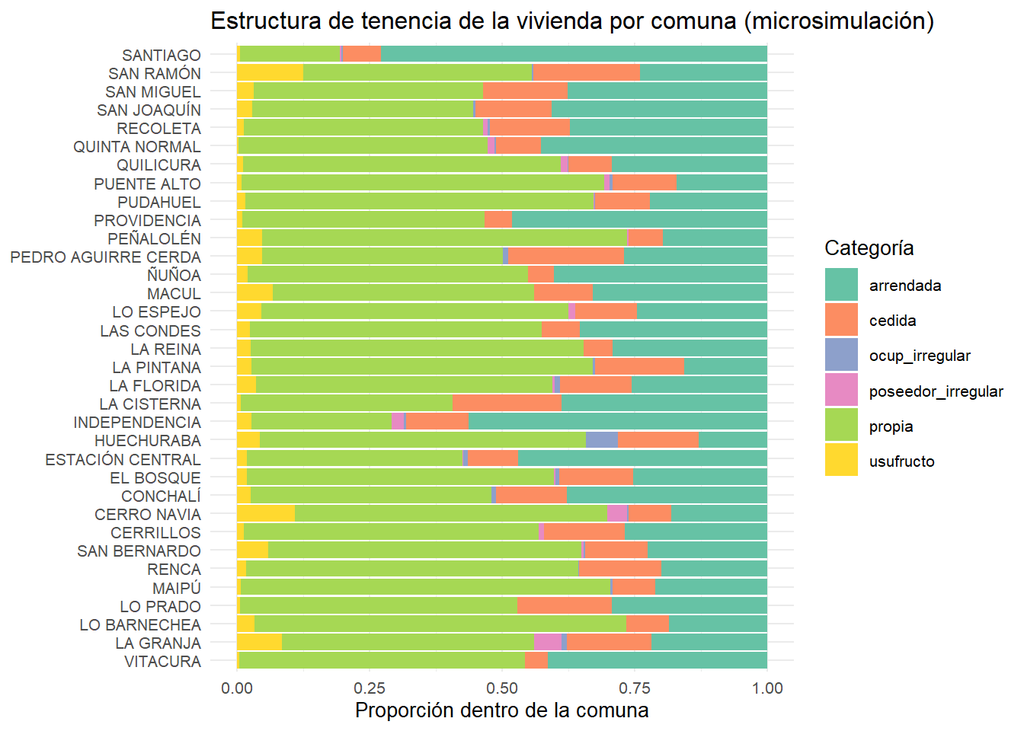

## 4.2 Resultado principal: Propietarios vs Arrendatarios

El índice *Arriendo - Propiedad* sintetiza la relación entre ambas formas de ocupación de la vivienda, permitiendo comparar su peso relativo en cada zona censal. En términos generales, la microsimulación muestra que la vivienda propia continua siendo el régimen de tenencia predominante, aunque con una presencia significativa del arriendo, lo que sugiere un proceso de diversificación en las formas de acceso a la vivienda.

Si se pasa al estudio espacial de la variable, resulta interesante observar que desde el centro hacía la periferia del Gran Santiago, existe una transformación en la situación de ocupación de la vivienda. En la zona centro tenemos el mayor índice de arriendo, sobre pasando en 50% las personas que arriendan por sobre los propietarios, mientras que cuando salimos del anillo de Américo Vespucio la situación se revierte. También existe una zona intermedia entre ambas zonas, donde la distribución de las proporciones es más pareja. Resulta lógico pensar, a partir de lo observado, que el crecimiento urbano que se ha dado en la periferia ha ido acompañado de personas que migran a esos sectores, donde existen más posibilidades de acceder y comprar una vivienda. Mientras que en el centro, los dueños de las propiedades han optado por vivir en otros sectores y arrendar sus viviendas por motivos que pueden tener muchas dimensiones.

Otro aspecto relevante a destacar, es que no existe mucha variaciones interna en cada comuna con respecto a la situación de ocupación, lo que tiene sentido en el contexto nacional, donde las comunas siempre han sido estigmatizadas más que los barrios, por lo que la gente opta por establecerse de una forma en particular en la comuna por sobre un barrio en específico. En general, la comunas son bastantes uniformes en la forma que ocupan la vivienda una persona, ya sea arrendando o siendo propietario.

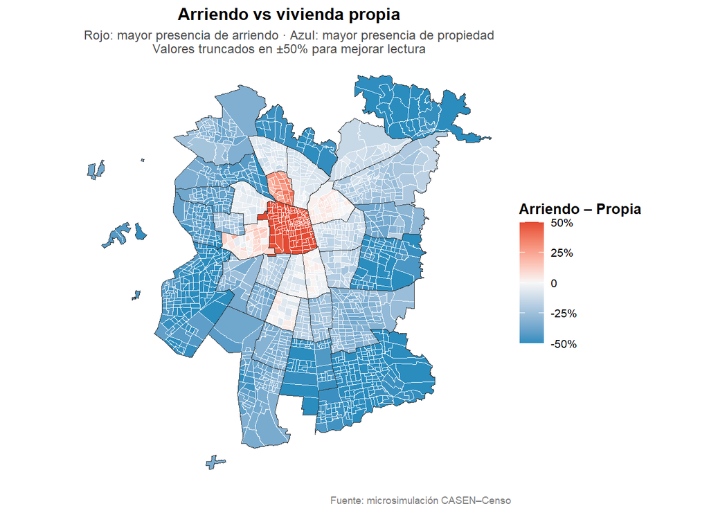

En cuanto a la densidad de arrendatarios y propietarios por zona censal, vemos que la mayor cola se concentra en valores negativos, lo que reafirman que la proporción de mayor consistencia corresponde a los propietarios, mientras que la cola positiva es el caso excepcional del centro del área metropolitana urbana. La gráfica también tiene sentido desde una perspectiva del tamaño y cantidad de las comunas, ya que en la periferia tenemos mayores zonas censales, por lo cuál la densidad de propietarios es aún mayor en comparación con las zonas más céntricas.

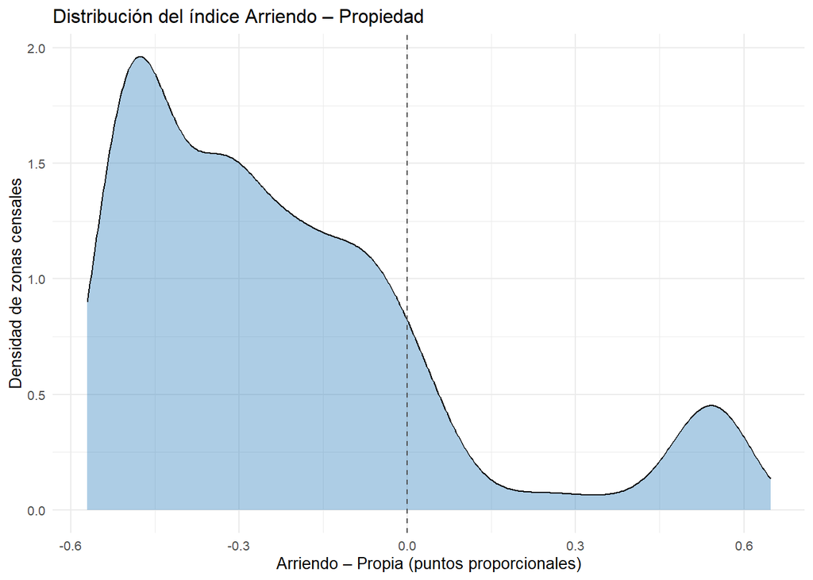

## 4.3 Proporciones generales

A continuación se presentan las proporciones simuladas de cada categoría de tenencia de la vivienda en el Gran Santiago.

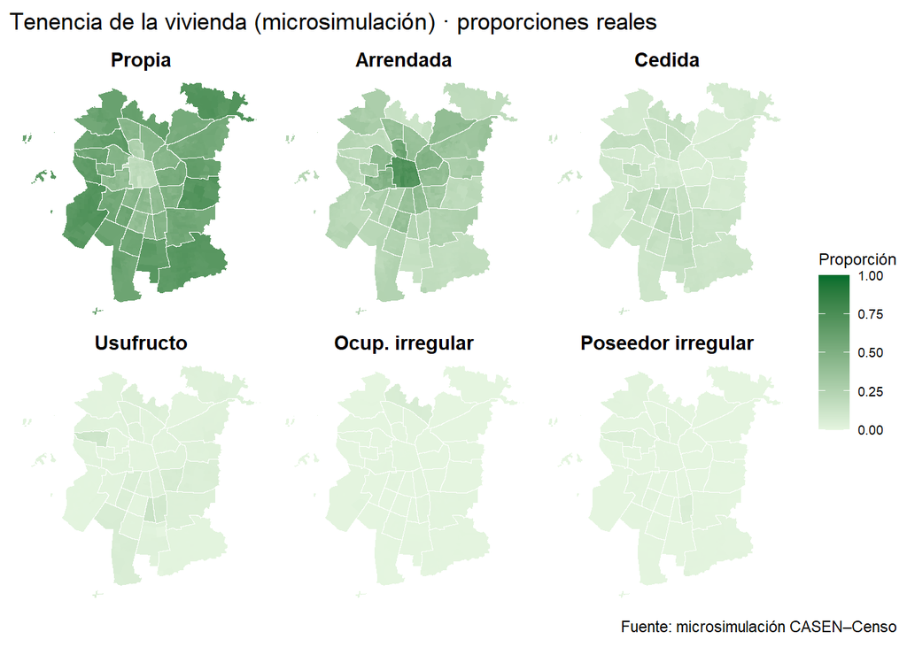

Como ya se mencionó, la vivienda propia constituye la modalidad predominante sobre todo en zonas de la periferia. En general, el resto de las categorías, excluyendo la arrendada, muestran valores muy bajos que dificultan encontrar patrones territoriales, los cuales no son captados por la forma en que se presentan los datos actualmente. Estos mapas solo confirmar la coherencia del modelo de microsimulación.

## 4.4 Proporciones normalizadas

Para estudiar en mayor detalle cada proporción, se normalizo cada una, para poder hallar patrones espaciales sobre todo en aquellas que representan una proporción muy baja del total.

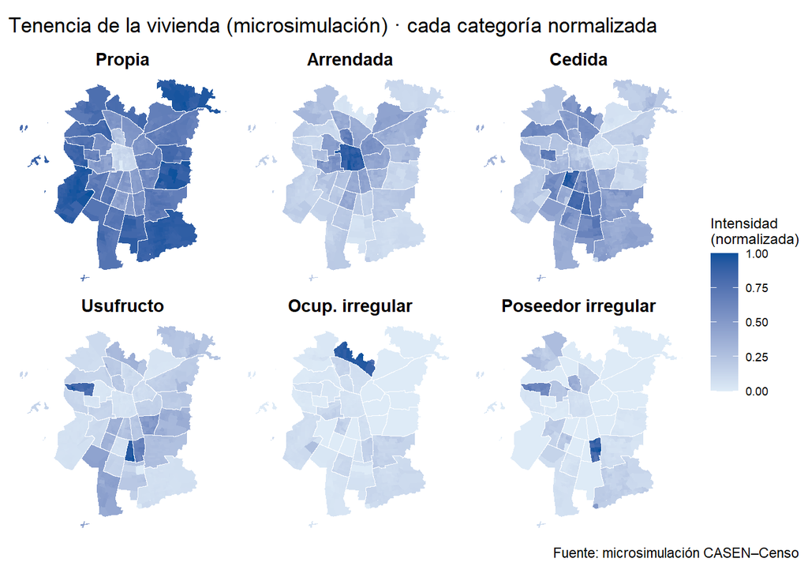

De esta forma, podemos observar que las viviendas cedidas se distribuyen en gran parte de la capital, pero existe una gran ausencia de este tipo de ocupación en sectores más acomodados como el oriente. Así mismo, las zonas con mayor nivel de este tipo ocurre en sectores más populares, como los del sur del Gran Santiago.

Resulta interesante el caso de ocupación irregular, donde la comuna con mayor intensidad en cuanto a la presencia de este tipo, es Huechuraba. Si bien existen otros sectores de la capital donde existan este tipo de situaciones, es probable que en esta comuna las personas hayan tenido más confianza para responder frente a su situación de ocupación.

Finalmente, la posesión irregular que esta presente en algunas comunas, tiene relación con los hogares que habitan una vivienda que consideran suya pero que no cuenta con un título de propiedad formal inscrito, diferente a la ocupación, donde se hace uso de una vivienda o terreno sin autorización legal del propietario. Es probable que las zonas que presentan mayor proporción de este tipo de situación existan ciertas condiciones históricas y urbanas como antigüedad del poblamiento y herencias sin regular o una débil formalización de títulos de dominio.

# 5. Conclusiones

La microsimulación planteada permitió estimar con alta coherencia la distribución de las formas de ocupación de la vivienda en el Gran Santiago, combinando la estructura demográfica del Censo 2017 con la información socioeconómica de la CASEN 2022. En general, los resultados muestran que la vivienda propia continúa siendo la modalidad predominante, aunque se observa que este fenómeno se acrecienta en zonas donde ha ido creciendo la urbanización.

La construcción del índice facilitó una lectura sintética del fenómeno, evidenciando las diferencias entre contextos donde predomina la estabilidad residencial y aquellos caracterizados por mayor movilidad y dependencia del mercado de arriendos. Asimismo, las categorías minoritarias aportan información valiosa sobre formas intermedias o precarias de tenencia, que suelen quedar subrepresentadas en estadísticas agregadas.

Metodológicamente, el uso de `rakeR` y la integración con PostgreSQL demostraron la capacidad de microsimulación para enlazar datos censales y muestrales, generando información espacialmente desagregada y consistente. El modelo podría ser mejorado escogiendo variables *constraints* que aporten mayor consistencia a la variable que se desea estudiar, de modo que se puedan visualizar patrones más específicos en el espacio.

Finalmente, el estudio evidencio una tendencia en abandonar el centro hacía zonas periféricas, donde se han adquiridos propiedades para vivir, a diferencia de zonas céntricas que a raíz de diferentes circunstancias, los propietarios han optado por el arriendo de sus inmuebles, generando una dinámica con consecuencias sociales en la estructura residencial del Gran Santiago.

# 6. Bibliografía

- **AUSTRALIAN INSTITUTE OF HEALTH AND WELFARE.** *Home ownership and housing tenure.* Canberra: AIHW, 2023. https://www.aihw.gov.au/reports/australias-welfare/home-ownership-and-housing-tenure
- **INSTITUTO NACIONAL DE ESTADÍSTICAS (INE).** *Censo de Población y Vivienda 2017: Resultados Definitivos.* Santiago de Chile: INE, 2018. https://www.ine.gob.cl/estadisticas/sociales/censos-de-poblacion-y-vivienda
- **MINISTERIO DE DESARROLLO SOCIAL Y FAMILIA (MDSF).** *Encuesta de Caracterización Socioeconómica Nacional (CASEN) 2022: Base de Datos y Metodología.* Santiago de Chile: MDSF, 2023. https://observatorio.ministeriodesarrollosocial.gob.cl/encuesta-casen
- **RAGAN-KELLY, M. et al.** *rakeR: Spatial Microsimulation in R.* Comprehensive R Archive Network (CRAN), 2021.  
  https://cran.r-project.org/package=rakeR
- **STANFORD UNIVERSITY.** *Generational Shifts in Age and Predictors of Homeownership.* Stanford Center on Longevity, 2018. https://longevity.stanford.edu/new-map-of-life-2021/wp-content/uploads/sites/36/2018/06/Generational-Shifts-in-Age-and-Predictors-of-Homeownership-1.pdf
- **WANG, H.; CHENG, Z.; et al.** *University education, homeownership and housing wealth.* *Education + Training*, 2022. https://www.sciencedirect.com/science/article/abs/pii/S1043951X21001607